# Exponential Smoothing

Duncan Mugford

March 04, 2022

```r
require(fpp3)
require(tidyquant)
require(slider)
require(tsibble)
require(seasonal)
require(seasonalview)
require(stargazer)
require(kableExtra)
require(fma)
```

```r
LBSNSA12 <- read.csv("C:\\Users\\chumb\\Documents\\Data\\LBSNSA12.csv")
```

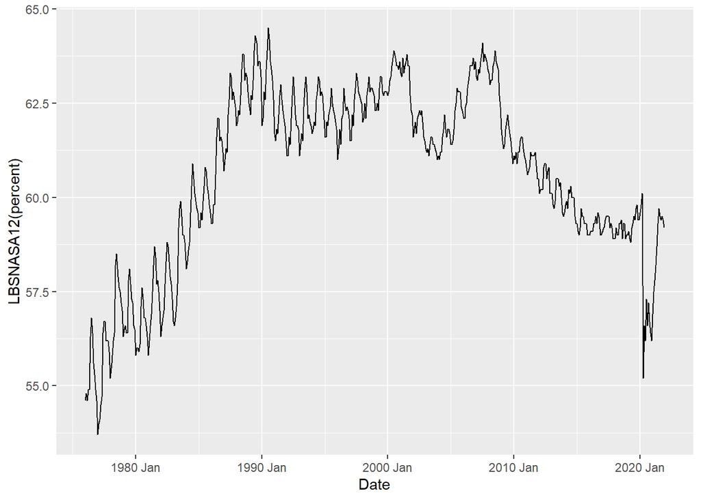

```r
VarList <- c("LBSNSA12")
training <-
tq_get(VarList, get = "economic.data", from = "1976-01-01") %>%
mutate(Month = yearmonth(date), Percent = price) %>%
select(-c(date,price)) %>%
as_tsibble(index = Month, key = symbol)

training %>%
  autoplot(Percent) +
  labs(x = "Date", y = "LBSNASA12(percent)")
```

```r
fitAuto <- training %>%
  model(ETS(Percent))
report(fitAuto)
```

```
## Series: Percent
## Model: ETS(A,N,A)
##   Smoothing parameters:
##     alpha = 0.7461688
##     gamma = 0.1923309
##
##   Initial states:
##      l[0]        s[0]     s[-1]     s[-2]    s[-3]     s[-4]    s[-5]     s[-6]
##  56.03619 -0.05659273 0.1342222 0.4841498 0.521318 0.9632655 1.179496 0.6412709
##       s[-7]      s[-8]      s[-9]     s[-10]     s[-11]
##  -0.6378136 -0.8848311 -0.7087699 -0.7172988 -0.9184167
##
##   sigma^2:  0.0994
##
##      AIC     AICc      BIC
## 2226.673 2227.569 2291.376
```

The automatic selection of ETS function chooses a model with additive error, no trend, and an additive seasonal adjustment – ETS(A,N,A). From Table 8.7 of FPP3, the estimated model specification is:

$y_{t}$ = $\ell_{t-1}$ + $s_{t-m}$ + $\epsilon_{t}$

$\ell_{t}$ = $\ell_{t-1}$ + 0.7461688$\epsilon_{t}$

$s_{t}$ = $s_{t-m}$ + 0.1923309$\epsilon_{t}$

with initial state level $\ell_{0}$ = 56.0361931, and initial seasonal states $s_0$,$s_-1$,…,$s_-11$.

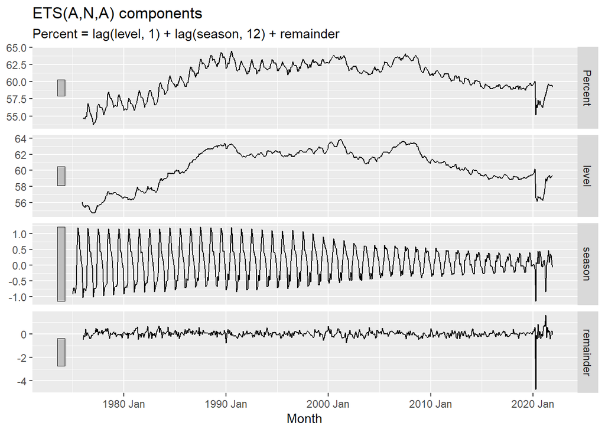

```r
components(fitAuto) %>%
  autoplot() +
  ggtitle("ETS(A,N,A) components")
```

Our components show us that there is a steep drop in 2020, most likely due to Covid, as well as that the seasonal effect is still prevalent over time but that the overall effect of it is diminishing.

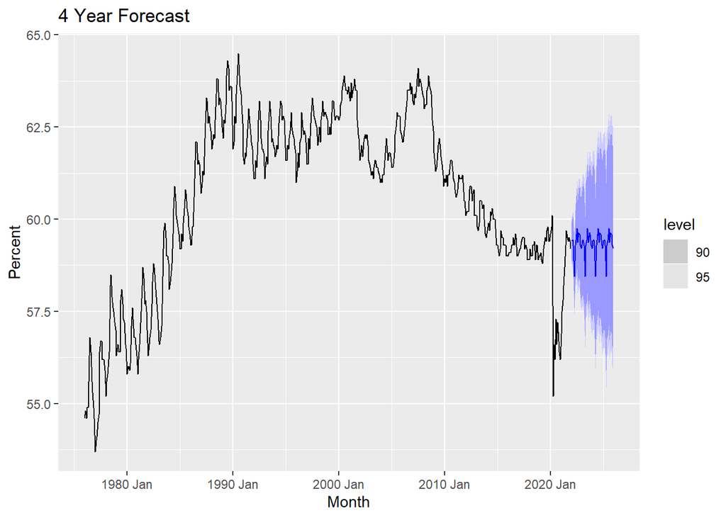

```r
fitAuto %>%
  forecast(h = 48) %>%
  autoplot(training, level = c(90,95)) +
  labs(x = "Month", y = "Percent", title = "4 Year Forecast")
```

```r
training %>%
  stretch_tsibble(.init=500) %>%
  model(
    `ETSANN` = ETS(Percent ~ error("A") + trend("N") + season("A"), opt_crit = "lik")) %>%
  forecast(h = 12) %>%
  accuracy(training)
```

| .model | symbol | .type | ME | RMSE | MAE | MPE | MAPE | MASE | RMSSE | ACF1 |
| --- | --- | --- | --- | --- | --- | --- | --- | --- | --- | --- |
| ETSANN | LBSNSA12 | Test | 0.003092091 | 1.545803 | 0.9694279 | -0.03114941 | 1.678627 | 1.522662 | 1.726702 | 0.8050964 |

Here, we are testing the accuracy of our model of best fit, the ETS(A,N,A) model. We know its the best fit model due to the fit test we ran above. Our MAPE accuracy shows us that the model should be accurate to about 1.7% when used to forecast the next season. However, it is important to note that this effect compounds over time so there is larger uncertainty the further out we forecast.